# Generating Cash Flow Expectations For Lending Club

Bryan Travis Smith, Ph.D

10/28/2016

# OC R User Group Meet-Up

This a a summary of the presentation I gave at the October [OC R User Group Meet](https://www.meetup.com/OC-RUG/). The focus on the talk was to solve the following problem statment using R.

> I am investing in Lending Club notes. Specifically Grade A, 36 Month loans. I want to generate an expected cash flow for my investment.

## Setup

I want to generate my expectations for grade A, 36 months loan. The main goal is to generate a framework for the solution that it can also be applied to other loans. I am starting off creating a data frame from all the join [Lending Club Data](https://www.lendingclub.com/info/download-data.action) from $Jun \ 30^{th}, 2016$ when I selected the target loans from tranches of loan that are mature.

```r
library(dplyr)
library(reshape2)
library(ggplot2)
library(zoo)
library(stringr)
library(DT)

# Previously loaded all LC data into a single data frame and saved as RData
load("/opt/science/Datasets/LendingClub/2016-06-30/lcCombinded.RData")

lcA <- lc %>% mutate(
    #Crate a Data Object for the Issue Date
    issue_yearmon = as.Date(as.yearmon(issue_d,format="%b-%Y")),
    #Create a Numeric Issue Year For Group By Calculations
    issue_year = as.numeric(as.character(issue_yearmon,format="%Y")),
    #Convert to Date object to calculate the 'Age' of the loan
    last_pymnt_yearmon = as.Date(as.yearmon(last_pymnt_d,format="%b-%Y")),
    #Converte interest rate to ta numeric value
    interest = as.numeric(str_replace(int_rate,"%",""))
  ) %>%
  mutate(
    #Make what are roughly 1 month wide in the time between the loan was
    #originated and the time it stopped generating cash flows
    AgeBucket = cut(as.numeric((last_pymnt_yearmon-issue_yearmon)/365),
                         breaks=seq(0,6,1/12),
                         include.lowest=T,
                         right=F)
    ) %>%
  mutate(
    #Converte the Age Bucket to a Numeric Month or Statement value
    Age = match(AgeBucket,levels(AgeBucket))
    ) %>%
  mutate(
    #Get the total recieved payments for each loan
    total_rec = total_rec_prncp+total_rec_int
    ) %>%
  #Limit to the data we are interested in for the problem
  #Remove 2007 - stands out in graphs, actually doesn't change the results too much.
  filter(term == " 36 months",grade == "A", issue_year  < 2013, issue_year > 2007)
```

## Cash Flow Expectation : Paid As Agreed

The simplest expectation is to just assume that everyone will make every schedule payment. The equation for the payment of a fix term loan is:

$$Payment = \frac{LoanAmount * MonthlyInterestRate}{1 - \frac{1}{(1+MonthlyInterestRate)^{Term}}}$$

You can then use this to get the amortization schedule for the loan.

```r
# Generates the expected payment for a fixed term loan.
payment_value <- function(loan_amount,interest_rate,term_number) {
  loan_amount*interest_rate/12/(1 - (1+interest_rate/12)^(-1*term_number))
}

#Gereates the scheduled payment behavior for a loan that is paid as agreed
get_amortization <- function(term_number,interest_rate){
  amortization <- data.frame(statement = seq(0,term_number,1),
                             payment = c(0,rep(payment_value(1,interest_rate,term_number),term_number)),
                             interest_payment = 0,
                             principal_payment = 0,
                             start_balance = 0,
                             end_balance = 1)
  for(i in (1:term_number+1)){
    amortization[i,'start_balance'] = amortization[i-1,'end_balance']*(1+interest_rate/12)
    amortization[i,'interest_payment'] = interest_rate*amortization[i-1,'end_balance']/12
    amortization[i,'principal_payment'] = amortization[i,'payment'] - amortization[i,'interest_payment']
    amortization[i,'end_balance'] = amortization[i,'start_balance']-amortization[i,'payment']
  }
  amortization[term_number+1,'end_balance']=0
  return(amortization)
}

#Helper function to round numeric values when writing to data table
round_df <- function(df, digits) {
  nums <- vapply(df, is.numeric, FUN.VALUE = logical(1))
  df[,nums] <- round(df[,nums], digits = digits)
  (df)
}

#Printing values
get_amortization(36,0.078) %>%
  round_df(4) %>%
  datatable(rownames=F)
```

| statement | payment | interest_payment | principal_payment | start_balance | end_balance |
| --- | --- | --- | --- | --- | --- |
| 0 | 0 | 0 | 0 | 0 | 1 |
| 1 | 0.0312 | 0.0065 | 0.0247 | 1.0065 | 0.9753 |
| 2 | 0.0312 | 0.0063 | 0.0249 | 0.9816 | 0.9504 |
| 3 | 0.0312 | 0.0062 | 0.0251 | 0.9565 | 0.9253 |
| 4 | 0.0312 | 0.006 | 0.0252 | 0.9313 | 0.9001 |
| 5 | 0.0312 | 0.0059 | 0.0254 | 0.9059 | 0.8747 |
| 6 | 0.0312 | 0.0057 | 0.0256 | 0.8803 | 0.8491 |
| 7 | 0.0312 | 0.0055 | 0.0257 | 0.8546 | 0.8234 |
| 8 | 0.0312 | 0.0054 | 0.0259 | 0.8287 | 0.7975 |
| 9 | 0.0312 | 0.0052 | 0.0261 | 0.8027 | 0.7714 |

[output cut: 27 more lines]

## Results: Paid As Agreed

I am now going to use the Lending Club data to caluclate actual yield of grade A, 36 month loans and compare it to the expectations generated by the above payment schedule. I will do this calcuation by year for each year of mature loans in Lending Club. We are assuming there is no prepayment and charge off behavior, so I will also calculate these to see scale of these behaviors.

```r
lcA %>%
  # Perform the following calculation for each year
  group_by(issue_year) %>%
  # Aggregrate for each year
  summarise(
    #Number of Loans
    Count = n(),
    #Dollars Loaned Out
    DollarsFunded = sum(funded_amnt),
    #Dollars collected from payments
    DollarsRecieved = sum(total_rec),
    #Percent Charge Offs
    Chargeoffs = round(sum(ifelse(grepl("Charged Off",loan_status),1,0))/Count*100,1),
    #Percent Prepayments
    Prepays = round(sum(ifelse(grepl("Fully Paid",loan_status)&(Age < 36),1,0))/Count*100,1),
    #The Percent Increase on the Dollars Loans
    Yield = round(100*(DollarsRecieved/DollarsFunded-1),1),
    #Dollar weighted interest rate for each year
    Interest = round(weighted.mean(interest,funded_amnt),1)) %>%
  mutate(
    #Applys the amortization schedule and sumes payments recieved for each loan
    ExpectedYield = apply( (.),
                             1,
                             function(x) sum(get_amortization(36,
                                                              as.numeric(x['Interest'])/100)$payment))) %>%
  mutate(
    #Rounds Expected Yield to a percent
    ExpectedYield = round(100*(ExpectedYield-1),1)) %>%
  #Filter to relevant variables
  select(issue_year,DollarsFunded,Prepays,Chargeoffs,Interest,Yield,ExpectedYield) %>%
  #Convert to % for display
  mutate(Prepays=paste0(Prepays,"%"),
         Chargeoffs=paste0(Chargeoffs,"%"),
         Interest=paste0(Interest,"%"),
         Yield=paste0(Yield,"%"),
         ExpectedYield = paste0(ExpectedYield,"%")) %>%
  #Create a data table
  datatable(rownames=F)
```

| issue_year | DollarsFunded | Prepays | Chargeoffs | Interest | Yield | ExpectedYield |
| --- | --- | --- | --- | --- | --- | --- |
| 2008 | 1899800 | 49.4% | 6% | 8.5% | 7.6% | 13.6% |
| 2009 | 8700550 | 49.7% | 6.7% | 8.8% | 7.6% | 14.1% |
| 2010 | 20650050 | 53.1% | 4.4% | 7.2% | 7.4% | 11.5% |
| 2011 | 49784200 | 50.9% | 6.4% | 7.2% | 6.4% | 11.5% |
| 2012 | 119545400 | 52.4% | 7.2% | 7.7% | 6.4% | 12.3% |

## Review: Paid As Agreed

I can see that there are signficant Prepayments and Charge Offs for each year of Lending Club, so I’ll try to include these in the expectations.

## Cash Flow Expectation : Account For Charge Offs

I am going to include charge offs in the payment expectations. Once a loan charges off, it no longer makes payments. This makes it straight forward to include in the amortatization schedule because we only need to keep track of how many loans are left, and add the payments of the left over loans. In reality there is also deliquency behavior that should be accounted for, but we will have to do that another time.

To execute this, I need to get get a feel for when the loans charge off in a given traunch of loans.

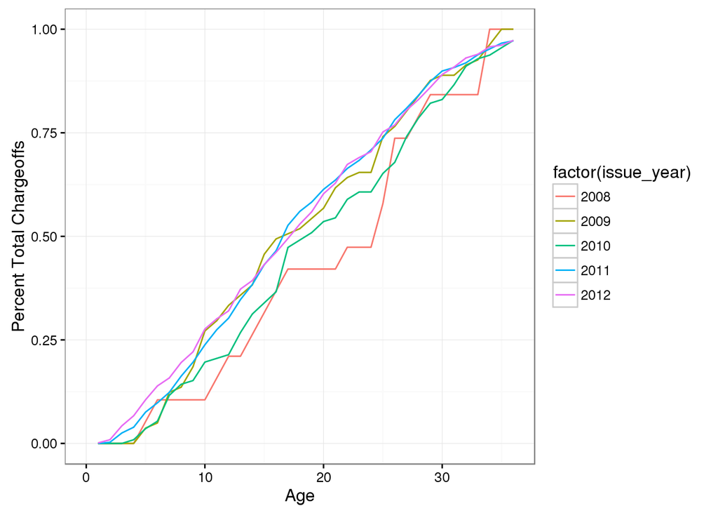

```r
# Charege Offs
lcA %>%
  #Perform the following calculations for each year
  group_by(issue_year) %>%
  ## Count the number of leans each year
  mutate(count=n()) %>%
  ## Perform a summary for each year and age of loan
  group_by(issue_year,Age) %>%
  ## Find the number of loans that charge off each month
  summarise(bad = sum(ifelse(grepl("Charged Off",loan_status),1,0)),
            #Get the count value for the year
            #count is a vector of the save value for each group
            count = max(count)) %>%
  ## ORder by the age for the cumsum
  arrange(Age) %>%
  ## Get the cumlative total of bad loans over the course of the term
  mutate(total_bad = cumsum(bad)) %>%
  ## Group by the traunch of loans
  group_by(issue_year) %>%
  ##Get the total number of bad loans for the traunch
  mutate(max_total_bad = max(total_bad)) %>%
  ##Plot the cumlative percentage of chargeoffs for each traunch
  ggplot(aes(Age,total_bad/max_total_bad,color=factor(issue_year)))+
  geom_line()+
  theme_bw()+
  xlim(0,36)+
  ylab('Percent Total Chargeoffs')
```

The cumlative chargeoff behavior has a characteristic shape, so we can use this shape to include in the expected number of units making payments in a given month. We can generate this expecations by just doing a weighted average on these curves (thought there are more thoughtful ways to do this as well). I’m going to take this average, and smoothing fit, and make a function of out it to include in the amortization of the loan.

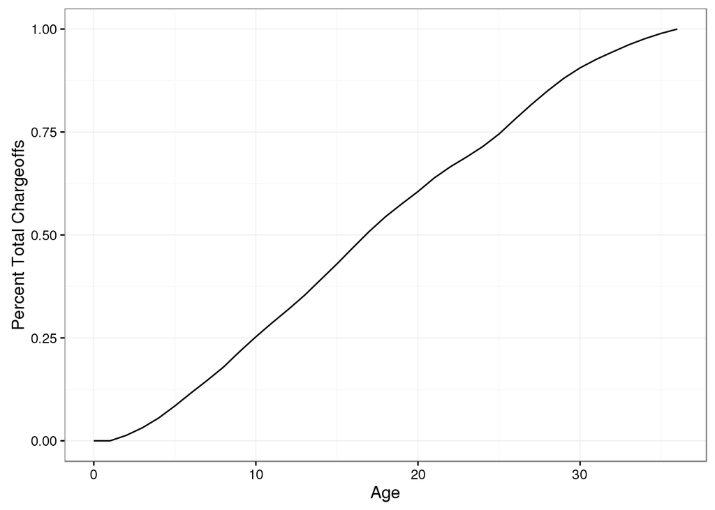

```r
percentChargeoffFunc <- lcA %>%
  #Perform the following calculations for each year
  group_by(issue_year) %>%
  ## Count the number of leans each year
  mutate(count=n()) %>%
  ## Perform a summary for each year and age of loan
  group_by(issue_year,Age) %>%
  ## Find the number of loans that charge off each month
  summarise(bad = sum(ifelse(grepl("Charged Off",loan_status),1,0)),
            #Get the count value for the year
            #count is a vector of the save value for each group
            count = max(count)) %>%
  ## ORder by the age for the cumsum
  arrange(Age) %>%
  ## Limit to 36 months
  filter(Age <= 36) %>%
  ## Get the cumlative total of bad loans over the course of the term
  mutate(total_bad = cumsum(bad)) %>%
  ## Group by the traunch of loans
  group_by(issue_year) %>%
  ##Get the total number of bad loans for the traunch
  mutate(max_total_bad = max(total_bad)) %>%
  ##Calculate percent bad
  mutate(percent_bad = total_bad/max_total_bad)  %>%
  ## Group by Age to do the weighted average of all the curves
  group_by(Age) %>%
  ## Calculate the weighted average by the traunch size
  summarise(avg_percent_total_bad = weighted.mean(percent_bad,count)) %>%
  ## Return Approx Function to describe Chargeoff Behavior
  (function(df) {
    ## Make a loess fit of the average to smooth out
    mod <- loess(avg_percent_total_bad ~ Age,df,span=1/4)
    ## make the predictions
    pred <- predict(mod,df)
    ## create a data frame of the age and smoothed predictions
    tmp <- data.frame(Age = df$Age,pred_percent_total_bad=pred)
    ## make sure the new smooth values are between 0 and 1
    tmp$pred_percent_total_bad = tmp$pred_percent_total_bad-min(tmp$pred_percent_total_bad)
    tmp$pred_percent_total_bad = tmp$pred_percent_total_bad/max(tmp$pred_percent_total_bad)
    # return approx function of the smooth function
    approxfun(tmp$Age,tmp$pred_percent_total_bad,method='linear',yleft = 0,yright=1)
  })

## Plot Function Output
data.frame(Age=seq(0,36),
           pco = percentChargeoffFunc(seq(0,36))) %>%
  ggplot(aes(Age,pco))+
  geom_line()+
  theme_bw()+
  xlim(0,36)+
  ylab('Percent Total Chargeoffs')
```

Now that I have the function, I can include the expected charge off function times the actual scale to update our cash flow expectations.

```r
#Ammortizaiton Schedule for loans with Charge Off Expectations
get_amortization_chargeoff <- function(term_number,interest_rate,percent_chargeoff){
  amortization <- data.frame(statement=seq(0,term_number,1),
                             payment=c(0,rep(payment_value(1,interest_rate,term_number),term_number)),
                             interest_payment = 0,
                             principal_payment=0,
                             start_balance=0,
                             end_balance=1,
                             #Added a units chargeoff which is the new curve times the measured scale
                             unit_chargeoff = percent_chargeoff*percentChargeoffFunc(seq(0,36)))
  for(i in (1:term_number+1)){
    amortization[i,'start_balance'] = amortization[i-1,'end_balance']*(1+interest_rate/12)
    amortization[i,'interest_payment'] = interest_rate*amortization[i-1,'end_balance']/12
    amortization[i,'principal_payment'] = amortization[i,'payment'] - amortization[i,'interest_payment']
    amortization[i,'end_balance'] = amortization[i,'start_balance']-amortization[i,'payment']
  }
  amortization[term_number+1,'end_balance']=0
  #Adds a payment recieved which is the schedule payments times the number of units left on a given statement
  amortization <- amortization %>% mutate(payment_recieved = (1-unit_chargeoff)*payment)
  return(amortization)
}

#Print output
get_amortization_chargeoff(36,0.07,0.06) %>%
  round_df(4) %>%
  datatable(rownames=F)
```

| statement | payment | interest_payment | principal_payment | start_balance | end_balance | unit_chargeoff | payment_recieved |
| --- | --- | --- | --- | --- | --- | --- | --- |
| 0 | 0 | 0 | 0 | 0 | 1 | 0 | 0 |
| 1 | 0.0309 | 0.0058 | 0.025 | 1.0058 | 0.975 | 0 | 0.0309 |
| 2 | 0.0309 | 0.0057 | 0.0252 | 0.9806 | 0.9498 | 0.0008 | 0.0309 |
| 3 | 0.0309 | 0.0055 | 0.0253 | 0.9553 | 0.9244 | 0.0019 | 0.0308 |
| 4 | 0.0309 | 0.0054 | 0.0255 | 0.9298 | 0.8989 | 0.0033 | 0.0308 |
| 5 | 0.0309 | 0.0052 | 0.0256 | 0.9042 | 0.8733 | 0.0051 | 0.0307 |
| 6 | 0.0309 | 0.0051 | 0.0258 | 0.8784 | 0.8475 | 0.007 | 0.0307 |
| 7 | 0.0309 | 0.0049 | 0.0259 | 0.8525 | 0.8216 | 0.0088 | 0.0306 |
| 8 | 0.0309 | 0.0048 | 0.0261 | 0.8264 | 0.7955 | 0.0107 | 0.0305 |
| 9 | 0.0309 | 0.0046 | 0.0262 | 0.8002 | 0.7693 | 0.013 | 0.0305 |

[output cut: 27 more lines]

## Results: Account For Charge Offs

```r
lcA %>%
  # Perform the following calculation for each year
  group_by(issue_year) %>%
  # Aggregrate for each year
  summarise(
    #Number of Loans
    Count = n(),
    #Dollars Loaned Out
    DollarsFunded = sum(funded_amnt),
    #Dollars collected from payments
    DollarsRecieved = sum(total_rec),
    #Percent Charge Offs
    Chargeoffs = round(sum(ifelse(grepl("Charged Off",loan_status),1,0))/Count*100,1),
    #Percent Prepayments
    Prepays = round(sum(ifelse(grepl("Fully Paid",loan_status)&(Age < 36),1,0))/Count*100,1),
    #The Percent Increase on the Dollars Loans
    Yield = round(100*(DollarsRecieved/DollarsFunded-1),1),
    #Dollar weighted interest rate for each year
    Interest = round(weighted.mean(interest,funded_amnt),1)) %>%
  mutate(
    #Applys the amortization schedule and sumes payments recieved for each loan
    ExpectedYield = apply( (.),
                              1,
                              function(x) sum(get_amortization_chargeoff(36,
                                                                         as.numeric(x['Interest'])/100,
                                                                         as.numeric(x['Chargeoffs'])/100
                              )$payment_recieved))) %>%
  mutate(
    #Rounds Expected Yield to a percent
    ExpectedYield = round(100*(ExpectedYield-1),1)
    ) %>%
  #Filter to relevant variables
  select(issue_year,DollarsFunded,Prepays,Chargeoffs,Interest,Yield,ExpectedYield) %>%
  #Convert to % for display
  mutate(Prepays=paste0(Prepays,"%"),
         Chargeoffs=paste0(Chargeoffs,"%"),
         Interest=paste0(Interest,"%"),
         Yield=paste0(Yield,"%"),
         ExpectedYield = paste0(ExpectedYield,"%")) %>%
  #Create a data table
  datatable(rownames=F)
```

| issue_year | DollarsFunded | Prepays | Chargeoffs | Interest | Yield | ExpectedYield |
| --- | --- | --- | --- | --- | --- | --- |
| 2008 | 1899800 | 49.4% | 6% | 8.5% | 7.6% | 10% |
| 2009 | 8700550 | 49.7% | 6.7% | 8.8% | 7.6% | 10.1% |
| 2010 | 20650050 | 53.1% | 4.4% | 7.2% | 7.4% | 8.9% |
| 2011 | 49784200 | 50.9% | 6.4% | 7.2% | 6.4% | 7.7% |
| 2012 | 119545400 | 52.4% | 7.2% | 7.7% | 6.4% | 8% |

## Review: Account For Charge Offs

I see that the expected values have decreased from the previous expectations. The expected and actuals are closer in line, but there is room for improvement. I have accounted for the charge offs, but not the prepayment behavior.

## Cash Flow Expectation : Account For Prepayments & Charge Offs

I can now repeat the process I did for including the effect of chargeoffs in our cash flow expectations. I can see if there is a characteristic cumlative behavior, generate a funciton that approximates the behavior, and incorporate it into the ammortization.

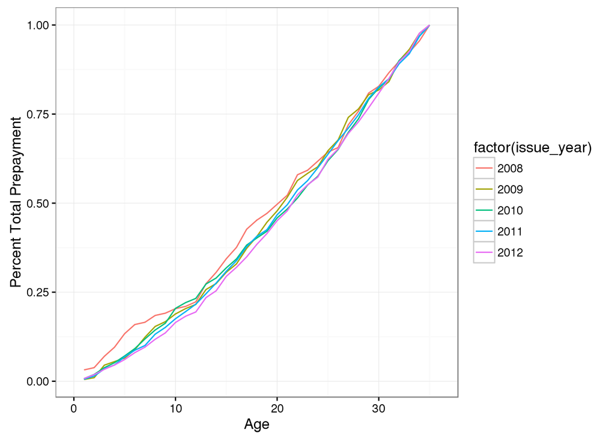

```r
# Prepays
lcA %>%
  ## Perform the following calculations for each year
  group_by(issue_year) %>%
  ## Count the number of leans each year
  mutate(count=n()) %>%
  ## Perform a summary for each year and age of loan
  group_by(issue_year,Age) %>%
  ## Find the number of loans that prepayments each month
  summarise(prepay = sum(ifelse(grepl("Fully Paid",loan_status),1,0)),
            ## Get the count value for the year
            ## count is a vector of the save value for each group
            count = max(count)) %>%
  ## ORder by the age for the cumsum
  arrange(Age) %>%
  ## Can only prepay before the loan is mature
  filter(Age < 36) %>%
  ## Get the cumlative total of prepaid loans over the course of the term
  mutate(total_prepay = cumsum(prepay)) %>%
  ## Group by the traunch of loans
  group_by(issue_year) %>%
  ## Get the total number of prepayments for the traunch
  mutate(max_total_prepay = max(total_prepay)) %>%
  ## Plot the cumlative percentage of prepaid loans for each traunch
  ggplot(aes(Age,total_prepay/max_total_prepay,color=factor(issue_year)))+
  geom_line()+
  theme_bw()+
  xlim(0,36)+
  ylab('Percent Total Prepayment')
```

The cumlative prepayment behavior over the life does have a characterist shape, so I will generate an approximation function similar to charge offs.

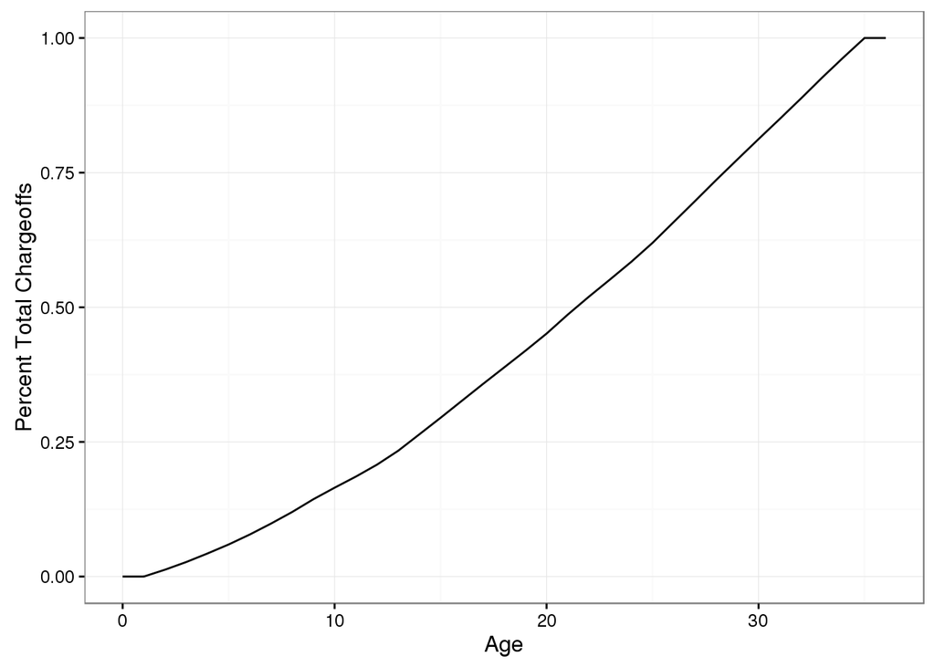

```r
percentPrepaymentFunc <- lcA %>%
  ## Perform the following calculations for each year
  group_by(issue_year) %>%
  ## Count the number of leans each year
  mutate(count=n()) %>%
  ## Perform a summary for each year and age of loan
  group_by(issue_year,Age) %>%
  ## Find the number of loans that prepayments each month
  summarise(prepay = sum(ifelse(grepl("Fully Paid",loan_status),1,0)),
            ## Get the count value for the year
            ## count is a vector of the save value for each group
            count = max(count)) %>%
  ## ORder by the age for the cumsum
  arrange(Age) %>%
  ## Can only prepay before the loan is mature
  filter(Age < 36) %>%
  ## Get the cumlative total of prepaid loans over the course of the term
  mutate(total_prepay = cumsum(prepay)) %>%
  ## Group by the traunch of loans
  group_by(issue_year) %>%
  ## Get the total number of prepayments for the traunch
  mutate(max_total_prepay = max(total_prepay))  %>%
  ## Calculate the percentage of prepayments that happen in a given
  ## month out of all of the prepayments that happen in the traunch
  mutate(percent_prepay = total_prepay/max_total_prepay) %>%
  ## Calculate for eeach age
  group_by(Age) %>%
  ##  The weighted mean of the percentage by the size of the traunch
  summarise(avg_percent_total_prepay = weighted.mean(percent_prepay,count)) %>%
  ## Return an approx function
  (function(df) {
    ## perform a loess fit to smoooth the function
    mod <- loess(avg_percent_total_prepay ~ Age,df,span=1/4)
    ## predict the results
    pred <- predict(mod,df)
    ## create a data frame to use to make the approx function
    tmp <- data.frame(Age = df$Age,pred_percent_total_prepay=pred)
    ## Make sure the fit produces values between 0 and 1
    tmp$pred_percent_total_prepay = tmp$pred_percent_total_prepay-min(tmp$pred_percent_total_prepay)
    tmp$pred_percent_total_prepay = tmp$pred_percent_total_prepay/max(tmp$pred_percent_total_prepay)
    ## Return the approx function
    approxfun(tmp$Age,tmp$pred_percent_total_prepay,method='linear',yleft = 0,yright=1)
  })

## Plot the approx functions
data.frame(Age=seq(0,36),
           ppp = percentPrepaymentFunc(seq(0,36))) %>%
  ggplot(aes(Age,ppp))+
  geom_line()+
  theme_bw()+
  xlim(0,36)+
  ylab('Percent Total Chargeoffs')
```

## Results: Account For Prepayments & Charge Offs

I have the characteristic prepayment function and charge off function, so I can append it to the ammortization schedule. Like loans that chargeoff, a prepaid loan does not generate payments after it is prepaid. Unlike charged off loans, it does return the prinipal. Once this is included, I suspect I will see higher than previously expected cashflows earlier due to returned principal.

```r
#Ammortizaiton Schedule for loans with Charge Off and Prepayment Expectations
get_amortization_chargeoff_prepay <- function(term_number,interest_rate,percent_chargeoff,percent_prepay){
  amortization <- data.frame(statement=seq(0,term_number,1),
                             payment=c(0,rep(payment_value(1,interest_rate,term_number),term_number)),
                             interest_payment = 0,
                             principal_payment=0,
                             start_balance=0,
                             end_balance=1,
                             #Units chargeoffed is measures scale * expected percent of total
                             unit_chargeoff = percent_chargeoff*percentChargeoffFunc(seq(0,36)),
                             #Units prepyament is measured scale * expected percent of total
                             unit_prepay = percent_prepay*percentPrepaymentFunc(seq(0,36)))
  for(i in (1:term_number+1)){
    amortization[i,'start_balance'] = amortization[i-1,'end_balance']*(1+interest_rate/12)
    amortization[i,'interest_payment'] = interest_rate*amortization[i-1,'end_balance']/12
    amortization[i,'principal_payment'] = amortization[i,'payment'] - amortization[i,'interest_payment']
    amortization[i,'end_balance'] = amortization[i,'start_balance']-amortization[i,'payment']
  }
  amortization[term_number+1,'end_balance']=0
  amortization <- amortization %>%
    mutate(monthly_prepay = ifelse(is.na(lag(unit_prepay)),0,unit_prepay-lag(unit_prepay))) %>%
    mutate(payment_recieved = (1-unit_chargeoff-unit_prepay)*payment+monthly_prepay*(end_balance+payment))
  return(amortization)
}


get_amortization_chargeoff_prepay(36,0.07,0.06,0.50) %>%
  round_df(4) %>%
  datatable(rownames=F)
```

| statement | payment | interest_payment | principal_payment | start_balance | end_balance | unit_chargeoff | unit_prepay | monthly_prepay | payment_recieved |
| --- | --- | --- | --- | --- | --- | --- | --- | --- | --- |
| 0 | 0 | 0 | 0 | 0 | 1 | 0 | 0 | 0 | 0 |
| 1 | 0.0309 | 0.0058 | 0.025 | 1.0058 | 0.975 | 0 | 0 | 0 | 0.0309 |
| 2 | 0.0309 | 0.0057 | 0.0252 | 0.9806 | 0.9498 | 0.0008 | 0.0064 | 0.0064 | 0.0369 |
| 3 | 0.0309 | 0.0055 | 0.0253 | 0.9553 | 0.9244 | 0.0019 | 0.0135 | 0.0071 | 0.0372 |
| 4 | 0.0309 | 0.0054 | 0.0255 | 0.9298 | 0.8989 | 0.0033 | 0.0214 | 0.0079 | 0.0375 |
| 5 | 0.0309 | 0.0052 | 0.0256 | 0.9042 | 0.8733 | 0.0051 | 0.0298 | 0.0084 | 0.0374 |
| 6 | 0.0309 | 0.0051 | 0.0258 | 0.8784 | 0.8475 | 0.007 | 0.039 | 0.0093 | 0.0376 |
| 7 | 0.0309 | 0.0049 | 0.0259 | 0.8525 | 0.8216 | 0.0088 | 0.0492 | 0.0101 | 0.0377 |
| 8 | 0.0309 | 0.0048 | 0.0261 | 0.8264 | 0.7955 | 0.0107 | 0.06 | 0.0108 | 0.0376 |
| 9 | 0.0309 | 0.0046 | 0.0262 | 0.8002 | 0.7693 | 0.013 | 0.0718 | 0.0118 | 0.0377 |

[output cut: 27 more lines]

Now I can add the prepayment behavior into our cashflows and compare the expected to the actuals.

```r
lcA %>%
  # Perform the following calculation for each year
  group_by(issue_year) %>%
  # Aggregrate for each year
  summarise(
    #Number of Loans
    Count = n(),
    #Dollars Loaned Out
    DollarsFunded = sum(funded_amnt),
    #Dollars collected from payments
    DollarsRecieved = sum(total_rec),
    #Percent Charge Offs
    Chargeoffs = round(sum(ifelse(grepl("Charged Off",loan_status),1,0))/Count*100,1),
    #Percent Prepayments
    Prepays = round(sum(ifelse(grepl("Fully Paid",loan_status)&(Age < 36),1,0))/Count*100,1),
    #The Percent Increase on the Dollars Loans
    Yield = round(100*(DollarsRecieved/DollarsFunded-1),1),
    #Dollar weighted interest rate for each year
    Interest = round(weighted.mean(interest,funded_amnt),1)) %>%
  mutate(
     #Applys the amortization schedule and sumes payments recieved for each loan
    ExpectedYield = apply( (.),
                              1,
                              function(x) sum(get_amortization_chargeoff_prepay(36,
                                                                         as.numeric(x['Interest'])/100,
                                                                         as.numeric(x['Chargeoffs'])/100,
                                                                         as.numeric(x['Prepays'])/100
                              )$payment_recieved))) %>%
  mutate(
    #Rounds Expected Yield to a percent
    ExpectedYield = round(100*(ExpectedYield-1),1)
    ) %>%
  #Filter to relevant variables
  select(issue_year,DollarsFunded,Prepays,Chargeoffs,Interest,Yield,ExpectedYield) %>%
  #Convert to % for display
  mutate(Prepays=paste0(Prepays,"%"),
         Chargeoffs=paste0(Chargeoffs,"%"),
         Interest=paste0(Interest,"%"),
         Yield=paste0(Yield,"%"),
         ExpectedYield = paste0(ExpectedYield,"%")) %>%
  #Create a data table
  datatable(rownames=F)
```

| issue_year | DollarsFunded | Prepays | Chargeoffs | Interest | Yield | ExpectedYield |
| --- | --- | --- | --- | --- | --- | --- |
| 2008 | 1899800 | 49.4% | 6% | 8.5% | 7.6% | 8.4% |
| 2009 | 8700550 | 49.7% | 6.7% | 8.8% | 7.6% | 8.3% |
| 2010 | 20650050 | 53.1% | 4.4% | 7.2% | 7.4% | 7.4% |
| 2011 | 49784200 | 50.9% | 6.4% | 7.2% | 6.4% | 6.3% |
| 2012 | 119545400 | 52.4% | 7.2% | 7.7% | 6.4% | 6.4% |

## Review: Account For Prepayments & Charge Offs

Now I have a framework for cashflow expectionats that comes within error of the actuals. This method requires that I generate expections for the expected charge off and prepayment scales to forecast cashflows, but once I have that, the rest is just straight forward math. The cashflow model that comes describes lending club actuals is using the paid as agreed model, then account for charge off and prepayment behavior. Even though there are a number of simplication and assumptions in this framework, it is an improved understanding of the expected cashflows for a grade A, 36 month term loan in Lending Club.